# Project 1

Author

Hector Gavilanes

```r
library(tidyverse)
library(gsheet)
library(formattable)
library(gridExtra)
```

**1. Members of the UWF basketball team decided to see if there was a difference in scoring on free throws during the first and second halves of games. Data was collected over thirteen games and is as follows:**

| 1st Half | 19 | 13 | 7 | 21 | 20 | 13 | 14 | 8 | 11 | 20 | 16 | 9 | 10 |
| --- | --- | --- | --- | --- | --- | --- | --- | --- | --- | --- | --- | --- | --- |
| **2nd Half** | **17** | **9** | **8** | **22** | **14** | **9** | **15** | **8** | **12** | **14** | **8** | **8** | **10** |

```r
# clear environment
rm(list = ls())
# data as vector
half_1 <- c(19, 13, 7, 21, 20, 13, 14, 8, 11, 20, 16, 9, 10)
half_2 <- c(17, 9, 8, 22, 14, 9, 15, 8, 12, 14, 8, 8, 10)

# create data frame
basketball <- tibble(half_1,half_2)
# transform table from wide to long
data_long <- basketball %>%
  drop_na() %>%
  pivot_longer(cols = half_1:half_2,
               names_to = "Half",
               values_to = "Scores")
# ---CUSTOM COLORS---
custom_green_dark = "#71CA97"
custom_green_light = "#DeF7E9"
custom_gray = "#3D3D3D"
custom_orange = "#FC7307"
custom_purple = "#5A18C9"
custom_tan_light = "#F7E3D4"
custom_density_hue = c(custom_purple,custom_orange)
# ---FUNCTIONS---
# f00 - Change default table format
change_table_format <- function(data_table){
  # local variables
  first_column <- data_table[1]
  dataframe_length <- NCOL(data_table)
  # format
  formattable(data_table, align = c("l",rep("c", dataframe_length - 1)),
              list(first_column = formatter("span", style = ~ style(color = custom_gray, font.weight = "bold")),
              area(row = 1, col = 2:dataframe_length) ~ color_tile(custom_green_light, custom_green_dark)
              )#/end list
              )#/end formattable
}
# f01 - get custom summary statistics
# !! sym() creates a symbol from a string
get_custom_summary <- function(data_table, category, values){
  summary <- data_table %>%
    group_by(!! sym(category)) %>%
    summarise(Avg = mean(!! sym(values)),
              Median = median(!! sym(values)),
              SD = sd(!! sym(values)),
              Min = min(!! sym(values)),
              Max = max(!! sym(values)),
              IQRange = IQR(!! sym(values))
              )
    return(summary)
}
```

**a. Find the appropriate summary statistics to summarize the data.**

```r
# summary statistics with custom table format
change_table_format(get_custom_summary(data_long, "Half","Scores"))
```

| Half | Avg | Median | SD | Min | Max | IQRange |
| --- | --- | --- | --- | --- | --- | --- |
| half_1 | 13.92308 | 13 | 4.889811 | 7 | 21 | 9 |
| half_2 | 11.84615 | 10 | 4.355957 | 8 | 22 | 6 |

**b. Perform the appropriate *t* test to determine if there is a difference in the number of free throws made during the first and second halves of games. Remember to typeset the hypothesis test results.**

```r
# dependent two.sided
t.test(basketball$half_1, basketball$half_2,
       paired = TRUE)
```

```
    Paired t-test

data:  basketball$half_1 and basketball$half_2
t = 2.359, df = 12, p-value = 0.03612
alternative hypothesis: true mean difference is not equal to 0
95 percent confidence interval:
 0.1586421 3.9952041
sample estimates:
mean difference
       2.076923
```

### Hypothesis

$H_0$: $\mu_{1st} = \mu_{2nd}$  
$H_1$: $\mu_{1st} \ne \mu_{2nd}$

### Test Statistics

$t_0 = 2.359$

### p-Value

$p = 0.036$

## Conclusion

Reject $H_0$ at the $\alpha$=0.05 level. There is sufficient evidence to suggest that there is a difference in the number of free throws made during the first and second halves of games.

**c. Perform the appropriate nonparametric test to determine if there is a difference in the number of free throws made during the first and second halves of games. Remember to typeset the hypothesis test results.**

```r
# dependent two.sided nonparametric
basket_wilcox <- wilcox.test(basketball$half_1, basketball$half_2,
            paired = TRUE,
            exact = FALSE)
```

### Hypothesis

$H_0$ : $M_{1st} = M_{2nd}$  
$H_1$ : $M_{1st} \ne M_{2nd}$

### Test Statistics

$t_0 = 54$

### p-Value

$p = 0.065$

**d. Construct the necessary graphs / hypothesis tests to assess the assumptions on the *t* test.**

### Assumption

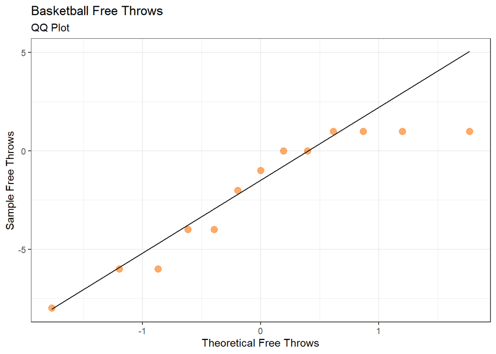

```r
graph_paired_qq_plot <- function(data_table, after_sample, before_sample){
  data_table %>%
    mutate(diff = after_sample - before_sample) %>%
    ggplot(aes(sample = diff)) +
    stat_qq(size=3, alpha = 0.6, color = custom_orange) +
    stat_qq_line() +
    theme_bw() +
    labs(title = "Basketball Free Throws", subtitle = "QQ Plot")+
    xlab("Theoretical Free Throws") +
    ylab("Sample Free Throws")
}
graph_paired_qq_plot(basketball, half_2, half_1)
```

```r
# summary statistics
# median by dependent samples
summary_long_table <- data_long %>%
  group_by(Half) %>%
  summarise_all(list(Median = median))

change_table_format(summary_long_table)
```

| Half | Median |
| --- | --- |
| half_1 | 13 |
| half_2 | 10 |

```r
# Basketball density
basketball_density <- data_long %>%
  group_by(Half) %>%
  ggplot(aes(x = Scores, color = Scores, fill = Half)) +
  geom_density(data = data_long, aes(color = Half), alpha = 0.25)+
  geom_vline(data = summary_long_table, aes(xintercept=Median, color=Half),
             linetype="dashed", size = 1.1)+
  annotate("text", x=12, y=0.025, label="Median", angle=90, size=5, color= custom_purple) +
  xlim(0,30)+
  ylab("Free Throws")+
  labs(title = "Basketball Free Throws", subtitle = "Density Plot")+
  theme_bw()+
  scale_fill_manual(values = custom_density_hue)+
  scale_color_manual(values = custom_density_hue)
```

**e. State the assumption(s) on the *t* test and provide your assessment based on results in part (d).**

The assumption of normality may not be valid. Normal distribution is not assumed.

**f. Based on your assessment in part (e), are you going to report the *t* test or the nonparametric test?**

The report will use the **nonparametric test**.

**g. Write a brief paragraph describing the results of your analysis. Include summary statistics, results of your chosen hypothesis test from part (f), and a graph to help convey the results.**

# UWF Basketball Free Throw Statistics Report

## Analysis

The first half has shown better scores. The team has more energy at the beginning of the match; therefore, they can make better free throws. The UWF basketball team has to improve stamina and concentration throughout the game. The team has to perform better under pressure.

### Summary Statistics

The following summary statistics displays the difference in scores.

| Half | Avg | Median | SD | Min | Max | IQRange |
| --- | --- | --- | --- | --- | --- | --- |
| half_1 | 13.92308 | 13 | 4.889811 | 7 | 21 | 9 |
| half_2 | 11.84615 | 10 | 4.355957 | 8 | 22 | 6 |

### NonParametric Test

#### Wilcoxon Test

```
    Wilcoxon signed rank test with continuity correction

data:  basketball$half_1 and basketball$half_2
V = 54, p-value = 0.06536
alternative hypothesis: true location shift is not equal to 0
```

#### Hypothesis

$H_0$ : $M_{1st} = M_{2nd}$  
$H_1$ : $M_{1st} \ne M_{2nd}$

#### Test Statistics

$t_0 = 54$

#### p-Value

$p = 0.065$

### Assumption

The assumption of normality may not be valid. The normal distribution is not assumed. The following QQ and Density plots demonstrate some discrepancies between the two halves.

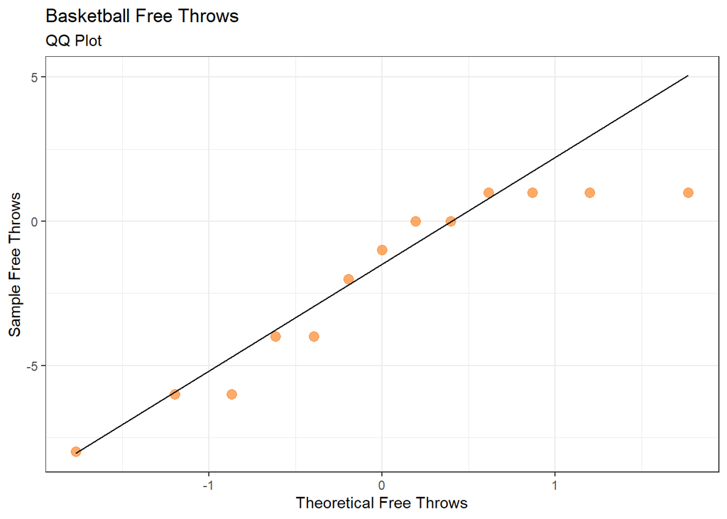

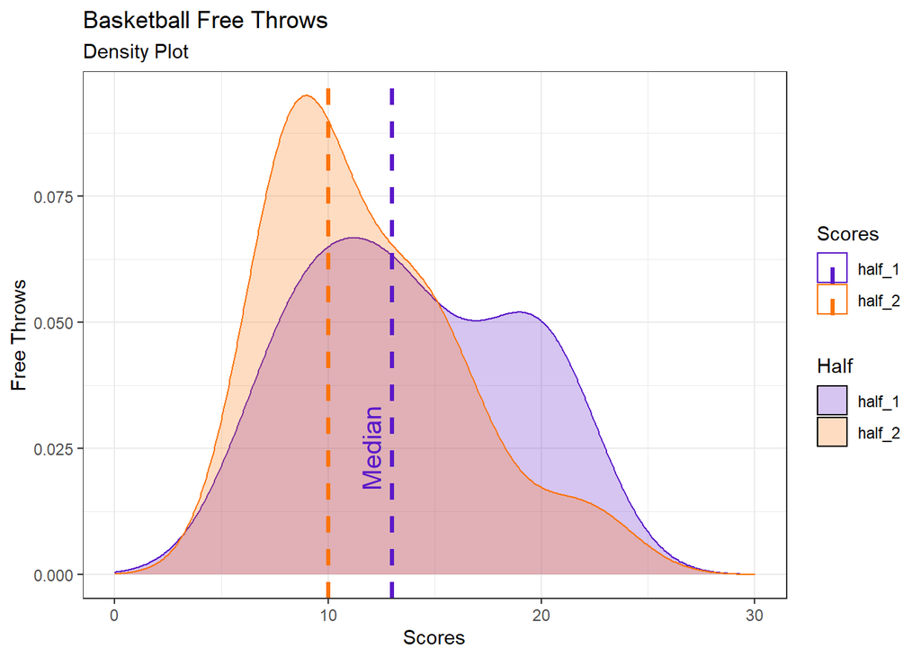

**2. It is hypothesized that students in College Algebra skip class less often than students in General Chemistry I; both courses seat 90 students. Data on the total number of absences per section was collected for one fall semester, and is as follows:**

| General Chemistry I | 161 | 140 | 136 | 171 | 106 | 149 |
| --- | --- | --- | --- | --- | --- | --- |
| **College Algebra** | **158** | **132** | **135** | **185** | **106** | **150** |

```r
# clear environment
#rm(list = ls())
# data as vector
chemistry <- c(161, 140, 136, 171, 106, 149)
algebra <- c(158, 132, 135, 185, 106, 150)

# create data frame
skip_class <- tibble(chemistry, algebra)
# transform table from wide to long
skip_long <- skip_class %>%
  drop_na() %>%
  pivot_longer(cols = chemistry: algebra,
               names_to = "Course",
               values_to = "Absence")
```

**a. Find the appropriate summary statistics to summarize the data.**

```r
change_table_format(get_custom_summary(skip_long, "Course", "Absence"))
```

| Course | Avg | Median | SD | Min | Max | IQRange |
| --- | --- | --- | --- | --- | --- | --- |
| algebra | 144.3333 | 142.5 | 26.76316 | 106 | 185 | 23.25 |
| chemistry | 143.8333 | 144.5 | 22.65760 | 106 | 171 | 21.00 |

**b. Perform the appropriate *t* test to determine if there are fewer absences in College Algebra. Remember to typeset the hypothesis test results.**

```r
# independent less
t.test(skip_long$Absence ~ skip_long$Course,
       alternative = "less")
```

```
    Welch Two Sample t-test

data:  skip_long$Absence by skip_long$Course
t = 0.034927, df = 9.7349, p-value = 0.5136
alternative hypothesis: true difference in means between group algebra and group chemistry is less than 0
95 percent confidence interval:
    -Inf 26.5185
sample estimates:
  mean in group algebra mean in group chemistry
               144.3333                143.8333
```

### Hypothesis

$H_0$: $\mu_{Algebra} \ge \mu_{Chemistry}$  
$H_1$: $\mu_{Algebra} < \mu_{Chemistry}$

### Test Statistics

$t_0 = 0.035$

### p-Value

$p = 0.51$

## Conclusion

Keep $H_0$ at the $\alpha$=0.05 level. There is not sufficient evidence to determine that there are fewer absences in College Algebra.

**c. Perform the appropriate nonparametric test to determine if there are fewer absences in College Algebra. Remember to typeset the hypothesis test results.**

```r
wilcox.test(skip_long$Absence ~ skip_long$Course,
            alternative = "less",
            exact = FALSE)
```

```
    Wilcoxon rank sum test with continuity correction

data:  skip_long$Absence by skip_long$Course
W = 16.5, p-value = 0.4363
alternative hypothesis: true location shift is less than 0
```

### Hypothesis

$H_0$: $M_{Algebra} \ge M_{Chemistry}$  
$H_1$: $M_{Algebra} < M_{Chemistry}$

### Test Statistics

$t_0 = 16.5$

### p-Value

$p = 0.44$

## Conclusion

Keep $H_0$ at the $\alpha$=0.05 level. There is not sufficient evidence to determine that there are fewer absences in College Algebra.

**d. Construct the necessary graphs / hypothesis tests to assess the assumptions on the *t* test.**

### Assumptions

#### QQ Plot

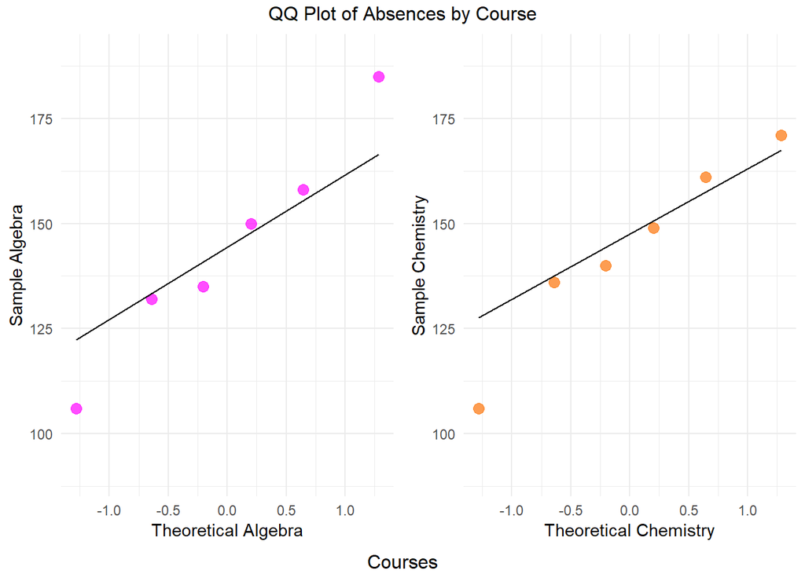

```r
# algebra qq
algebra_qq <- skip_long %>%
  filter(Course == "algebra") %>%
  ggplot(aes(sample = Absence)) +
  stat_qq(size=3, alpha = 0.7, color = "magenta") +
  stat_qq_line() +
  theme_minimal() +
  xlab("Theoretical Algebra") +
  ylab("Sample Algebra")+
  ylim(90, 190)
# chemistry qq
chemistry_qq <- skip_long %>%
  filter(Course == "chemistry") %>%
  ggplot(aes(sample = Absence)) +
  stat_qq(size=3, alpha = 0.7, color = custom_orange) +
  stat_qq_line() +
  theme_minimal() +
  xlab("Theoretical Chemistry") +
  ylab("Sample Chemistry")+
  ylim(90, 190)
# Combine both graphs
grid.arrange(algebra_qq, chemistry_qq, nrow=1, bottom = "Courses", top = "QQ Plot of Absences by Course")
```

### Assumption Supporting Graph

```r
# median by courses
groups_median <- skip_long %>%
  group_by(Course) %>%
  summarise(Median = median(Absence))
change_table_format(groups_median)
```

| Course | Median |
| --- | --- |
| algebra | 142.5 |
| chemistry | 144.5 |

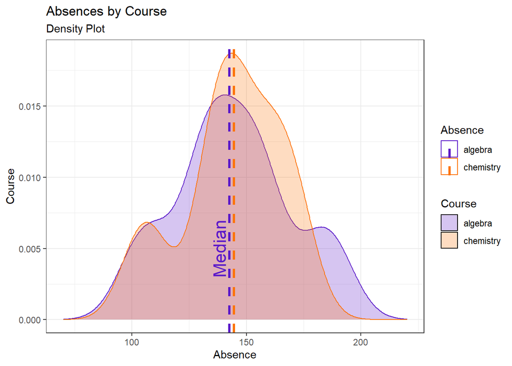

```r
# absences density
absence_density <- skip_long %>%
  group_by(Course) %>%
  ggplot(aes(x = Absence, colour = Absence, fill = Course)) +
  geom_density(data = skip_long, aes(color = Course), alpha = 0.25)+
  geom_vline(data = groups_median, aes(xintercept=Median, color=Course),
             linetype="dashed", size = 1.1)+
  annotate("text", x=138, y=0.005, label="Median", angle=90, size=6, color=custom_purple)+
  labs(title = "Absences by Course", subtitle = "Density Plot")+
  ylab("Course")+
  theme(legend.position="bottom")+
  theme_bw()+
  scale_fill_manual(values = custom_density_hue)+
  scale_color_manual(values = custom_density_hue)+
  xlim(70,220)

absence_density
```

**e. State the assumption(s) on the *t* test and provide your assessment based on results in part (d).**

The assumption of normality may be valid. Normal distribution is assumed.

**f. Based on your assessment in part (e), are you going to report the *t* test or the nonparametric test?**

The report will use the **T-test**.

**g. Write a brief paragraph describing the results of your analysis. Include summary statistics, results of your chosen hypothesis test from part (f), and a graph to help convey the results.**

# Number of Absences per Course Report

## Analisys

### Summary Statistics

The following summary statistics displays the difference in absences per course.

| Course | Avg | Median | SD | Min | Max | IQRange |
| --- | --- | --- | --- | --- | --- | --- |
| algebra | 144.3333 | 142.5 | 26.76316 | 106 | 185 | 23.25 |
| chemistry | 143.8333 | 144.5 | 22.65760 | 106 | 171 | 21.00 |

### T-test

```
    Welch Two Sample t-test

data:  skip_long$Absence by skip_long$Course
t = 0.034927, df = 9.7349, p-value = 0.5136
alternative hypothesis: true difference in means between group algebra and group chemistry is less than 0
95 percent confidence interval:
    -Inf 26.5185
sample estimates:
  mean in group algebra mean in group chemistry
               144.3333                143.8333
```

#### Hypothesis

$H_0$: $\mu_{Algebra} \ge \mu_{Chemistry}$  
$H_1$: $\mu_{Algebra} < \mu_{Chemistry}$

#### Test Statistics

$t_0 = 0.035$

#### p-Value

$p = 0.51$

### Conclusion

Keep $H_0$ at the $\alpha$=0.05 level. There is not sufficient evidence to determine that there are fewer absences in College Algebra.

### Assumption

The assumption of normality may be valid. The normal distribution is assumed. The following QQ and Density plots demonstrate how the data match the general appearance of a normal distribution.

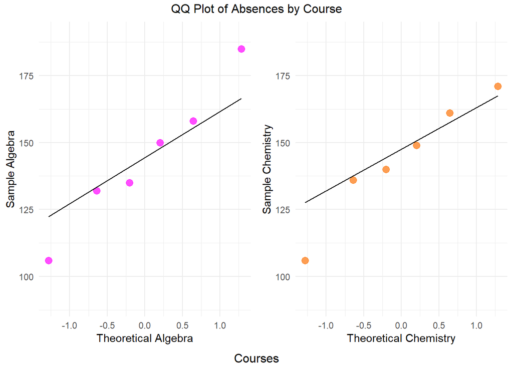

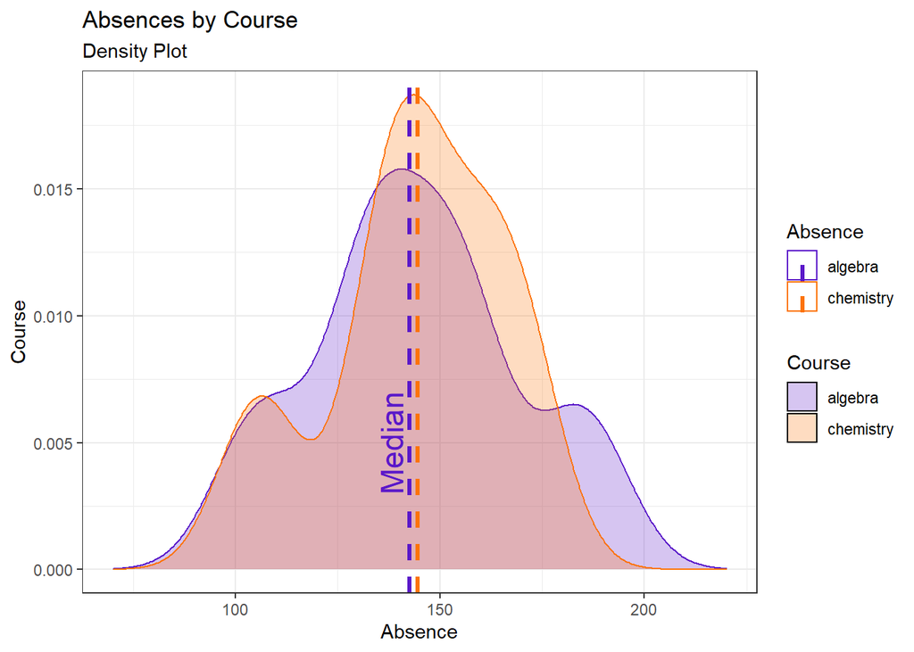